# W5_class_notes

# Analysis

DayCare.html DayCare.Rmd

# Day 1 ANOVA One way

## Example 1 - ANOVA for KidsFeet

```r
library(mosaic)
View(KidsFeet)
```

Do an ANOVA for the KidsFeet dataframe

```r
aovOut <- aov(
  length ~ as.factor(birthmonth),
  data = KidsFeet
  )

summary(aovOut)
```

```
##                       Df Sum Sq Mean Sq F value Pr(>F)
## as.factor(birthmonth) 11  11.58   1.053   0.523  0.871
## Residuals             27  54.39   2.014
```

### Side note - as.factor()

as.factor() changes a column type. In this case, we changed birthmonth so that it’s not a numeric type and is a factor type instead. This was necessary because the ANOVA attempted originally couldn’t calculate the degrees of freedom properly since it thought the values were quantitative when they were really qualitative.

```r
class(KidsFeet$birthmonth)
```

```
## [1] "integer"
```

### Side note - droplevels()

I’ve worked with this before, but we talked about how when you filter data it only HIDES what you didn’t want to see, but doesn’t delete it. You need to use droplevels() to actually get rid of the things you filtered out.

## Requirements

1 - you need th data to be representative of the population.

2 - You neet to confirm that the data has a constant variance.

```r
#par(mfrow=c(1,2))
#plot(chick.aov, which =1, pch=16)
```

3 - To test for normality you will need to Q-Q plot the residuals

```r
#qqPlot(chick.aov$residuals, id=FALSE)
```

## Getting a F value

F is the test statistic, or F value for ANOVA.

## ONe-way anova mathematival model

i = represents how many groups you have

k = represents how many items are in each group.

# Day 2 ANOVA Two way

```r
library(car)
library(tidyverse)
```

```r
library(mosaic)
```

```r
View(Blackmore)
?Blackmore
```

```
## starting httpd help server ... done
```

```r
Blackmore$ageGroup <- cut(Blackmore$age, c(7,10,12,14,18), labels=c("Youth","Pre-Teen","Early-Teen","Late-Teen"))



#OR



library(tidyverse) #way to do it

Blackmore <- Blackmore %>%
   mutate(ageGroup = cut(age, c(7,10,12,14,18), labels=c("Youth","Pre-Teen", "Early-Teen", "Late-Teen"), ordered_result = TRUE))
```

```r
table(Blackmore$ageGroup)
```

```
##
##      Youth   Pre-Teen Early-Teen  Late-Teen
##        460        178        141        166
```

```r
View(Blackmore)
```

Perform a two-way ANOVA in R using the group and ageGroup factors, including their interaction term, to understand how average exercise differs between the various levels of each factor.

To check your work, enter the degrees of freedom (Df) for each of the following:

```r
myaov <- aov(
  exercise ~ group+ageGroup+group:ageGroup,
  data = Blackmore)

summary(myaov)
```

```
##                 Df Sum Sq Mean Sq F value   Pr(>F)
## group            1    459   458.6   47.02 1.27e-11 ***
## ageGroup         3   1493   497.8   51.04  < 2e-16 ***
## group:ageGroup   3    442   147.4   15.12 1.30e-09 ***
## Residuals      937   9137     9.8
## ---
## Signif. codes:  0 '***' 0.001 '**' 0.01 '*' 0.05 '.' 0.1 ' ' 1
```

# Skills Quiz - ANOVA

Run the code “View(warpbreaks)” in R. Use that data set to identify each of the following as either a “factor” or a “level” of a factor.

```r
View(warpbreaks)
```

## Question 3

These questions test your ability to read ANOVA output from R.

Run the following commands in R using the Friendly data set (Recalling Words).

```r
library(car)
friendly.aov <- aov(
  correct ~ condition,
  data=Friendly)

summary(friendly.aov)
```

```
##             Df Sum Sq Mean Sq F value Pr(>F)
## condition    2  264.6  132.30   4.341 0.0232 *
## Residuals   27  822.9   30.48
## ---
## Signif. codes:  0 '***' 0.001 '**' 0.01 '*' 0.05 '.' 0.1 ' ' 1
```

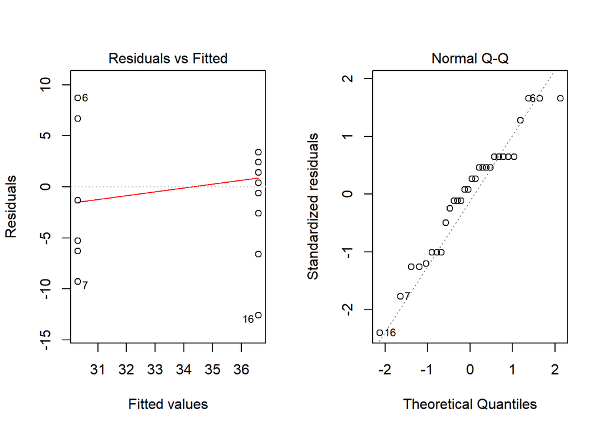

```r
par(mfrow=c(1,2))

plot(friendly.aov, which=1:2)
```

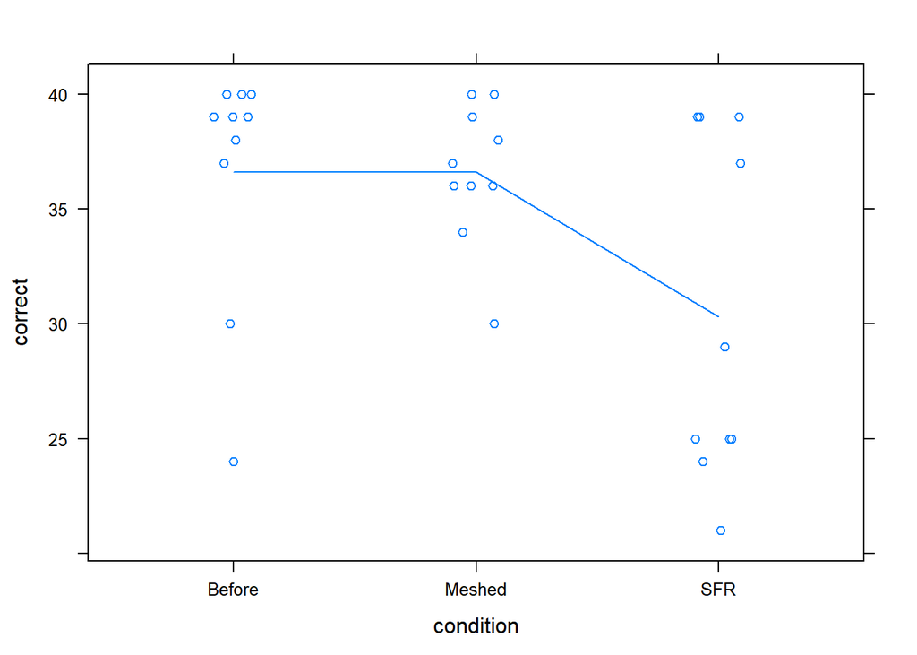

```r
library(lattice)
xyplot(correct ~ condition, data=Friendly, jitter.x=TRUE, type=c("p","a"))
```

## Question 4

```r
?ToothGrowth
View(ToothGrowth)
```

```r
as.factor(ToothGrowth$dose)
```

```
##  [1] 0.5 0.5 0.5 0.5 0.5 0.5 0.5 0.5 0.5 0.5 1   1   1   1   1   1   1   1   1
## [20] 1   2   2   2   2   2   2   2   2   2   2   0.5 0.5 0.5 0.5 0.5 0.5 0.5 0.5
## [39] 0.5 0.5 1   1   1   1   1   1   1   1   1   1   2   2   2   2   2   2   2
## [58] 2   2   2
## Levels: 0.5 1 2
```

```r
ToothGrowth.aov <- aov(
  len ~ supp + as.factor(dose)+supp:as.factor(dose),
  data = ToothGrowth
)

summary(ToothGrowth.aov)
```

```
##                      Df Sum Sq Mean Sq F value   Pr(>F)
## supp                  1  205.4   205.4  15.572 0.000231 ***
## as.factor(dose)       2 2426.4  1213.2  92.000  < 2e-16 ***
## supp:as.factor(dose)  2  108.3    54.2   4.107 0.021860 *
## Residuals            54  712.1    13.2
## ---
## Signif. codes:  0 '***' 0.001 '**' 0.01 '*' 0.05 '.' 0.1 ' ' 1
```

```r
par()
```

[output not shown]

[output cut: 160 more lines]

[output not shown]

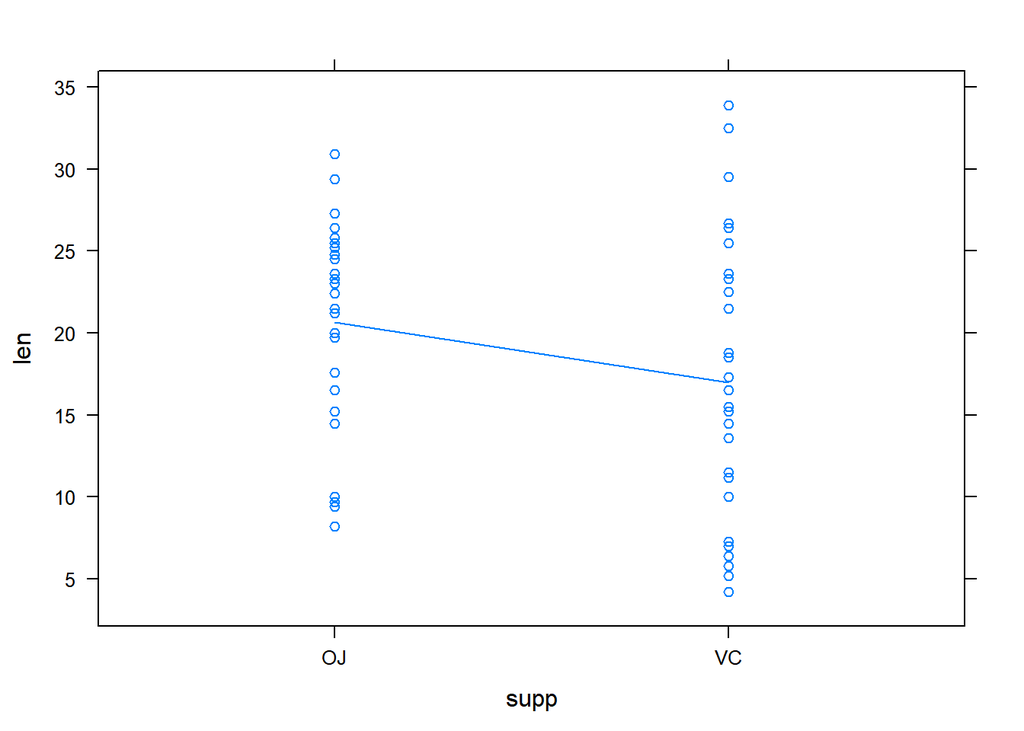

```r
xyplot( len ~ supp, data=ToothGrowth, type=c("p","a"))
```

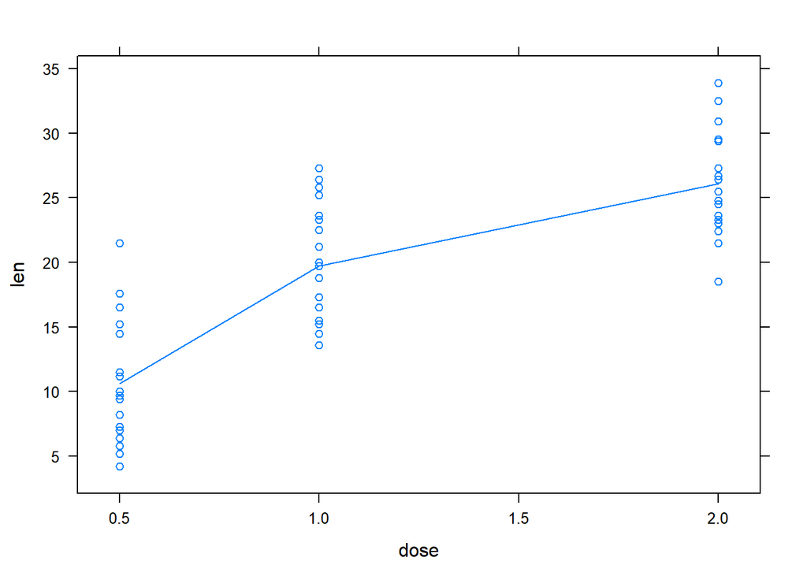

```r
xyplot( len ~ dose, data=ToothGrowth, type=c("p","a"))
```

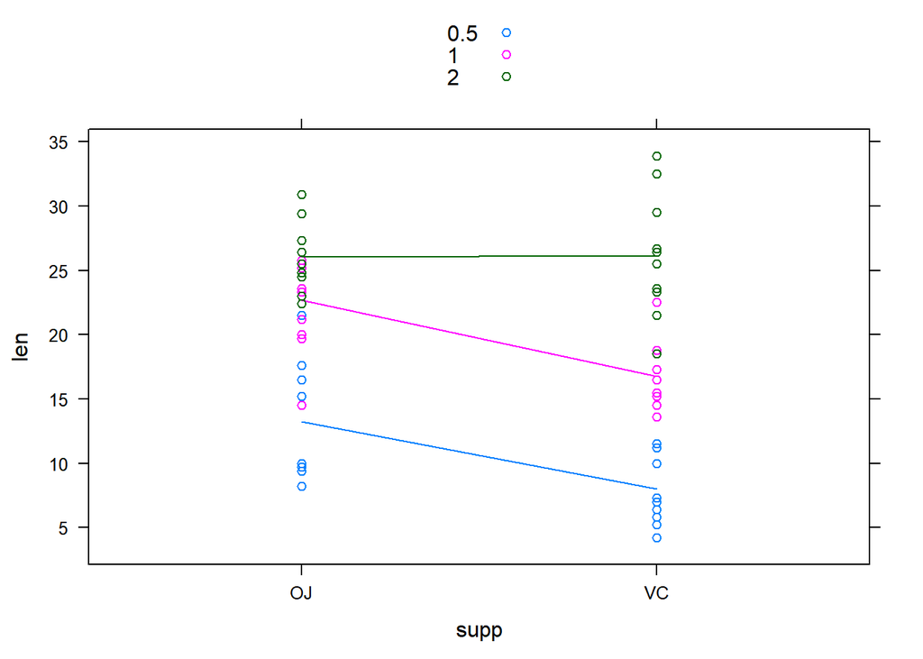

```r
xyplot( len ~ supp, data=ToothGrowth, groups=dose, type=c("p","a"), auto.key=TRUE)
```